# Central Limit Theorem Example

Albert Y. Kim

Last updated on 2022-03-21

# Terminology/Concept Refresher:

- A *population distribution* is the distribution from which individual observations originate. i.e. individual dragon wing spans
- A *(random) sample of size $n$* is a random sample of $n$ observations from the population distribution. i.e. a sample of $n$ dragons
- A *sample statistic* is a summary statistic based on the sample. In our case, we’ll be considering the sample mean dragon wing span
- A *sampling distribution* is the distribution from which sample statistics originate. In our case, it is the distribution from which observed sample means originate
- The *standard error* is the standard deviation specifically associated with a sampling distribution.
- The *Central Limit Theorem* states as the sample size $n$ increases, the sampling distribution of the sample mean gets more normal and narrower. This happens even if the population distribution is not normal.

# Central Limit Theorem example

## Population distribution

We demonstrate the Central Limit Theorem assuming that dragon wing spans from from the following right-skewed and non-normal population distribution. **i.e. Individual dragon wing spans follow this distribution.**

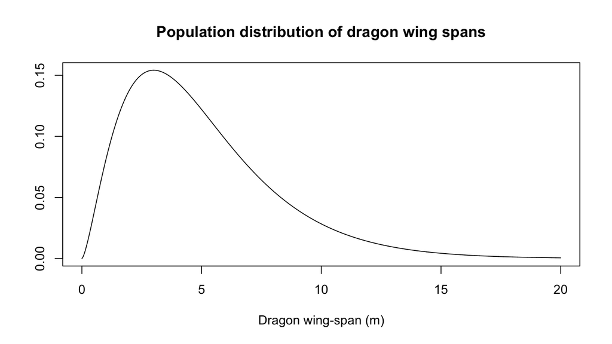

## Sampling distributions

Much as we did in class, we’ll

1. Take random samples of size $n$ from the population distribution
2. Compute the sample mean of these $n$ wing-spans i.e. the average wing-span
3. Simulate this procedure 1000 times
4. Plot the distribution of 1000 resulting sample means

This plots are the sampling distribution of the sample mean. **i.e. The average wing-spans of the samples of size n follow this distribution.** We do this for $n$ = 1, 2, 4, 6, 10, and 15:

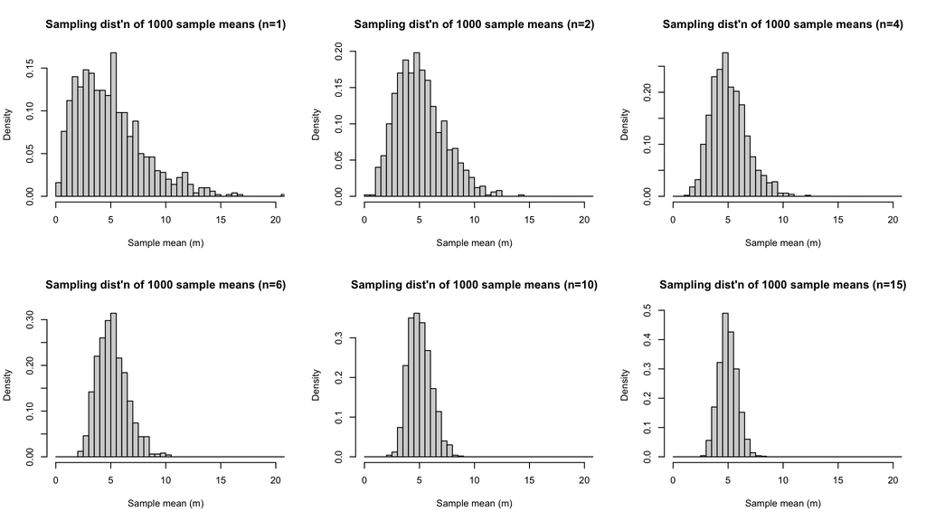

**Moral**: We just demonstrated the Central Limit Theorem. As the sample size increases, the sampling distribution of sample means and sample proportions gets more normal and more narrow. This happens irregardless of the shape of the population distribution.